# Risk Factor Analysis

## Outcome Variable

**Outcome Variable:** swasted

## Predictor Variables

**Intervention Variable:** exclfeed36

**Adjustment Set:**

- arm
- sex
- W_mage
- meducyrs
- feducyrs
- hhwealth_quart
- hfoodsec
- W_mhtcm
- vagbrth
- W_gagebrth
- W_birthwt
- W_birthlen
- W_nrooms
- W_nchldlt5
- month
- brthmon
- W_parity
- impfloor
- impsan
- safeh20
- delta_W_mage
- delta_meducyrs
- delta_feducyrs
- delta_hhwealth_quart
- delta_hfoodsec
- delta_W_mhtcm
- delta_vagbrth
- delta_W_gagebrth
- delta_W_birthwt
- delta_W_birthlen
- delta_W_nrooms
- delta_W_nchldlt5
- delta_month
- delta_brthmon
- delta_W_parity
- delta_impfloor
- delta_impsan
- delta_safeh20

## Stratifying Variables

The analysis was stratified on these variable(s):

- agecat
- studyid
- country

## Data Summary

| agecat | studyid | country | exclfeed36 | swasted | n_cell | n |
| --- | --- | --- | --- | --- | --- | --- |
| Birth | ki0047075b-MAL-ED | BANGLADESH | 0 | 0 | 164 | 230 |
| Birth | ki0047075b-MAL-ED | BANGLADESH | 0 | 1 | 8 | 230 |
| Birth | ki0047075b-MAL-ED | BANGLADESH | 1 | 0 | 58 | 230 |
| Birth | ki0047075b-MAL-ED | BANGLADESH | 1 | 1 | 0 | 230 |
| Birth | ki0047075b-MAL-ED | BRAZIL | 0 | 0 | 165 | 177 |
| Birth | ki0047075b-MAL-ED | BRAZIL | 0 | 1 | 0 | 177 |
| Birth | ki0047075b-MAL-ED | BRAZIL | 1 | 0 | 12 | 177 |
| Birth | ki0047075b-MAL-ED | BRAZIL | 1 | 1 | 0 | 177 |
| Birth | ki0047075b-MAL-ED | INDIA | 0 | 0 | 183 | 195 |
| Birth | ki0047075b-MAL-ED | INDIA | 0 | 1 | 7 | 195 |
| Birth | ki0047075b-MAL-ED | INDIA | 1 | 0 | 5 | 195 |
| Birth | ki0047075b-MAL-ED | INDIA | 1 | 1 | 0 | 195 |
| Birth | ki0047075b-MAL-ED | NEPAL | 0 | 0 | 152 | 167 |
| Birth | ki0047075b-MAL-ED | NEPAL | 0 | 1 | 4 | 167 |
| Birth | ki0047075b-MAL-ED | NEPAL | 1 | 0 | 11 | 167 |
| Birth | ki0047075b-MAL-ED | NEPAL | 1 | 1 | 0 | 167 |
| Birth | ki0047075b-MAL-ED | PERU | 0 | 0 | 251 | 266 |
| Birth | ki0047075b-MAL-ED | PERU | 0 | 1 | 0 | 266 |
| Birth | ki0047075b-MAL-ED | PERU | 1 | 0 | 15 | 266 |
| Birth | ki0047075b-MAL-ED | PERU | 1 | 1 | 0 | 266 |
| Birth | ki0047075b-MAL-ED | SOUTH AFRICA | 0 | 0 | 233 | 234 |
| Birth | ki0047075b-MAL-ED | SOUTH AFRICA | 0 | 1 | 1 | 234 |
| Birth | ki0047075b-MAL-ED | SOUTH AFRICA | 1 | 0 | 0 | 234 |
| Birth | ki0047075b-MAL-ED | SOUTH AFRICA | 1 | 1 | 0 | 234 |
| Birth | ki0047075b-MAL-ED | TANZANIA, UNITED REPUBLIC OF | 0 | 0 | 114 | 116 |
| Birth | ki0047075b-MAL-ED | TANZANIA, UNITED REPUBLIC OF | 0 | 1 | 1 | 116 |
| Birth | ki0047075b-MAL-ED | TANZANIA, UNITED REPUBLIC OF | 1 | 0 | 1 | 116 |
| Birth | ki0047075b-MAL-ED | TANZANIA, UNITED REPUBLIC OF | 1 | 1 | 0 | 116 |
| Birth | ki1000108-CMC-V-BCS-2002 | INDIA | 0 | 0 | 0 | 3 |
| Birth | ki1000108-CMC-V-BCS-2002 | INDIA | 0 | 1 | 0 | 3 |

[output cut: 150 more lines]

The following strata were considered:

- agecat: 24 months, studyid: ki0047075b-MAL-ED, country: BANGLADESH
- agecat: 24 months, studyid: ki0047075b-MAL-ED, country: BRAZIL
- agecat: 24 months, studyid: ki0047075b-MAL-ED, country: INDIA
- agecat: 24 months, studyid: ki0047075b-MAL-ED, country: NEPAL
- agecat: 24 months, studyid: ki0047075b-MAL-ED, country: PERU
- agecat: 24 months, studyid: ki0047075b-MAL-ED, country: SOUTH AFRICA
- agecat: 24 months, studyid: ki0047075b-MAL-ED, country: TANZANIA, UNITED REPUBLIC OF
- agecat: 24 months, studyid: ki1000108-CMC-V-BCS-2002, country: INDIA
- agecat: 24 months, studyid: ki1000108-IRC, country: INDIA
- agecat: 24 months, studyid: ki1017093b-PROVIDE, country: BANGLADESH
- agecat: 24 months, studyid: ki1101329-Keneba, country: GAMBIA
- agecat: 24 months, studyid: ki1113344-GMS-Nepal, country: NEPAL
- agecat: 24 months, studyid: ki1148112-LCNI-5, country: MALAWI
- agecat: 24 months, studyid: kiGH5241-JiVitA-3, country: BANGLADESH
- agecat: 24 months, studyid: kiGH5241-JiVitA-4, country: BANGLADESH
- agecat: 6 months, studyid: ki0047075b-MAL-ED, country: BANGLADESH
- agecat: 6 months, studyid: ki0047075b-MAL-ED, country: BRAZIL
- agecat: 6 months, studyid: ki0047075b-MAL-ED, country: INDIA
- agecat: 6 months, studyid: ki0047075b-MAL-ED, country: NEPAL
- agecat: 6 months, studyid: ki0047075b-MAL-ED, country: PERU
- agecat: 6 months, studyid: ki0047075b-MAL-ED, country: SOUTH AFRICA
- agecat: 6 months, studyid: ki0047075b-MAL-ED, country: TANZANIA, UNITED REPUBLIC OF
- agecat: 6 months, studyid: ki1000108-CMC-V-BCS-2002, country: INDIA
- agecat: 6 months, studyid: ki1000108-IRC, country: INDIA
- agecat: 6 months, studyid: ki1000109-EE, country: PAKISTAN
- agecat: 6 months, studyid: ki1000304b-SAS-FoodSuppl, country: INDIA
- agecat: 6 months, studyid: ki1017093b-PROVIDE, country: BANGLADESH
- agecat: 6 months, studyid: ki1101329-Keneba, country: GAMBIA
- agecat: 6 months, studyid: ki1113344-GMS-Nepal, country: NEPAL
- agecat: 6 months, studyid: ki1148112-LCNI-5, country: MALAWI
- agecat: 6 months, studyid: kiGH5241-JiVitA-3, country: BANGLADESH
- agecat: 6 months, studyid: kiGH5241-JiVitA-4, country: BANGLADESH
- agecat: Birth, studyid: ki0047075b-MAL-ED, country: BANGLADESH
- agecat: Birth, studyid: ki0047075b-MAL-ED, country: BRAZIL
- agecat: Birth, studyid: ki0047075b-MAL-ED, country: INDIA
- agecat: Birth, studyid: ki0047075b-MAL-ED, country: NEPAL
- agecat: Birth, studyid: ki0047075b-MAL-ED, country: PERU
- agecat: Birth, studyid: ki0047075b-MAL-ED, country: SOUTH AFRICA
- agecat: Birth, studyid: ki0047075b-MAL-ED, country: TANZANIA, UNITED REPUBLIC OF
- agecat: Birth, studyid: ki1000108-CMC-V-BCS-2002, country: INDIA
- agecat: Birth, studyid: ki1000108-IRC, country: INDIA
- agecat: Birth, studyid: ki1000109-EE, country: PAKISTAN
- agecat: Birth, studyid: ki1101329-Keneba, country: GAMBIA
- agecat: Birth, studyid: kiGH5241-JiVitA-3, country: BANGLADESH
- agecat: Birth, studyid: kiGH5241-JiVitA-4, country: BANGLADESH

### Dropped Strata

Some strata were dropped due to rare outcomes:

- agecat: Birth, studyid: ki0047075b-MAL-ED, country: BANGLADESH
- agecat: Birth, studyid: ki0047075b-MAL-ED, country: BRAZIL
- agecat: Birth, studyid: ki0047075b-MAL-ED, country: INDIA
- agecat: Birth, studyid: ki0047075b-MAL-ED, country: NEPAL
- agecat: Birth, studyid: ki0047075b-MAL-ED, country: PERU
- agecat: Birth, studyid: ki0047075b-MAL-ED, country: SOUTH AFRICA
- agecat: Birth, studyid: ki0047075b-MAL-ED, country: TANZANIA, UNITED REPUBLIC OF
- agecat: Birth, studyid: ki1000108-CMC-V-BCS-2002, country: INDIA
- agecat: Birth, studyid: ki1000108-IRC, country: INDIA
- agecat: Birth, studyid: ki1000109-EE, country: PAKISTAN
- agecat: Birth, studyid: ki1101329-Keneba, country: GAMBIA
- agecat: Birth, studyid: kiGH5241-JiVitA-4, country: BANGLADESH
- agecat: 6 months, studyid: ki0047075b-MAL-ED, country: BANGLADESH
- agecat: 6 months, studyid: ki0047075b-MAL-ED, country: BRAZIL
- agecat: 6 months, studyid: ki0047075b-MAL-ED, country: INDIA
- agecat: 6 months, studyid: ki0047075b-MAL-ED, country: NEPAL
- agecat: 6 months, studyid: ki0047075b-MAL-ED, country: PERU
- agecat: 6 months, studyid: ki0047075b-MAL-ED, country: SOUTH AFRICA
- agecat: 6 months, studyid: ki0047075b-MAL-ED, country: TANZANIA, UNITED REPUBLIC OF
- agecat: 6 months, studyid: ki1000108-CMC-V-BCS-2002, country: INDIA
- agecat: 6 months, studyid: ki1000108-IRC, country: INDIA
- agecat: 6 months, studyid: ki1000109-EE, country: PAKISTAN
- agecat: 6 months, studyid: ki1000304b-SAS-FoodSuppl, country: INDIA
- agecat: 6 months, studyid: ki1017093b-PROVIDE, country: BANGLADESH
- agecat: 6 months, studyid: ki1113344-GMS-Nepal, country: NEPAL
- agecat: 6 months, studyid: ki1148112-LCNI-5, country: MALAWI
- agecat: 24 months, studyid: ki0047075b-MAL-ED, country: BANGLADESH
- agecat: 24 months, studyid: ki0047075b-MAL-ED, country: BRAZIL
- agecat: 24 months, studyid: ki0047075b-MAL-ED, country: INDIA
- agecat: 24 months, studyid: ki0047075b-MAL-ED, country: NEPAL
- agecat: 24 months, studyid: ki0047075b-MAL-ED, country: PERU
- agecat: 24 months, studyid: ki0047075b-MAL-ED, country: SOUTH AFRICA
- agecat: 24 months, studyid: ki0047075b-MAL-ED, country: TANZANIA, UNITED REPUBLIC OF
- agecat: 24 months, studyid: ki1000108-CMC-V-BCS-2002, country: INDIA
- agecat: 24 months, studyid: ki1000108-IRC, country: INDIA
- agecat: 24 months, studyid: ki1017093b-PROVIDE, country: BANGLADESH
- agecat: 24 months, studyid: ki1148112-LCNI-5, country: MALAWI

## Methods Detail

We’re interested in the causal parameters $E[Y_a]$ for all values of $a \in \mathcal{A}$. These parameters represent the mean outcome if, possibly contrary to fact, we intervened to set all units to have $A=a$. Under the randomization and positivity assumptions, these are identified by the statistical parameters $\psi_a=E_W[E_{Y|A,W}(Y|A=a,W)]$. In addition, we’re interested in the mean of $Y$, $E[Y]$ under no intervention (the observed mean). We will estimate these parameters by using SuperLearner to fit the relevant likelihood factors – $E_{Y|A,W}(Y|A=a,W)$ and $p(A=a|W)$, and then updating our likelihood fit using a joint TMLE.

For unadjusted analyses ($W=\{\}$), initial likelihoods were estimated using Lrnr_glm to estimate the simple $E(Y|A)$ and Lrnr_mean to estimate $p(A)$. For adjusted analyses, a small library containing Lrnr_glmnet, Lrnr_xgboost, and Lrnr_mean was used.

Having estimated these parameters, we will then use the delta method to estimate relative risks and attributable risks relative to a prespecified baseline level of $A$.

# Results Detail

## Results Plots

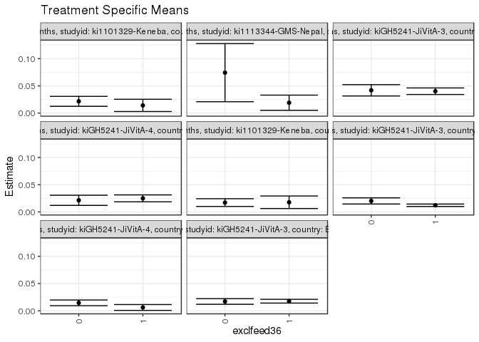

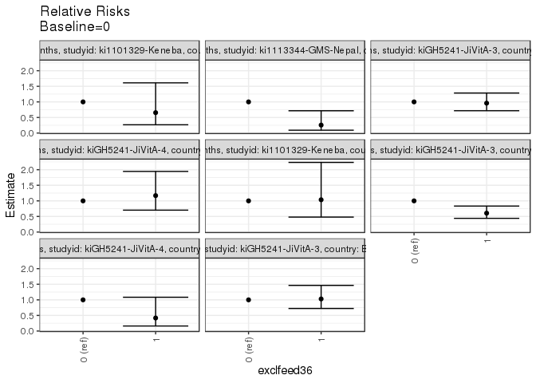

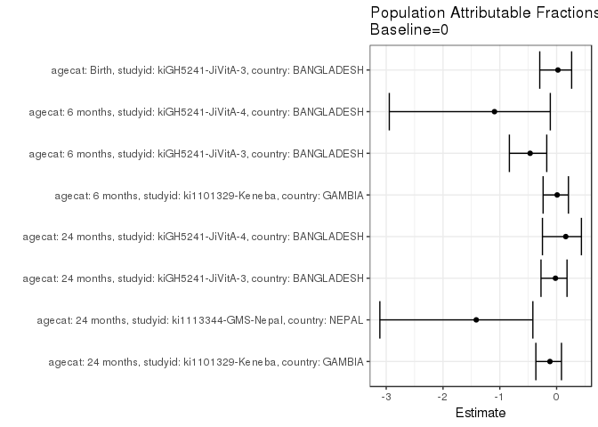

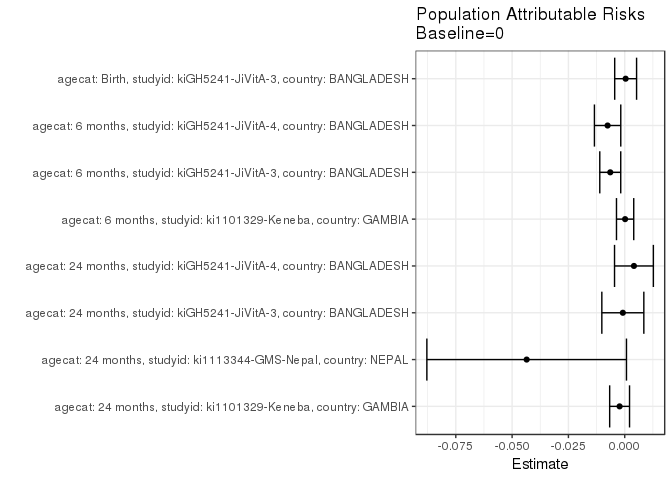

## Results Table

### Parameter: TSM

| agecat | studyid | country | intervention_level | baseline_level | estimate | ci_lower | ci_upper |
| --- | --- | --- | --- | --- | --- | --- | --- |
| Birth | kiGH5241-JiVitA-3 | BANGLADESH | 0 | NA | 0.0170860 | 0.0119093 | 0.0222628 |
| Birth | kiGH5241-JiVitA-3 | BANGLADESH | 1 | NA | 0.0175821 | 0.0141317 | 0.0210325 |
| 6 months | ki1101329-Keneba | GAMBIA | 0 | NA | 0.0171473 | 0.0100418 | 0.0242529 |
| 6 months | ki1101329-Keneba | GAMBIA | 1 | NA | 0.0177515 | 0.0062542 | 0.0292487 |
| 6 months | kiGH5241-JiVitA-3 | BANGLADESH | 0 | NA | 0.0202030 | 0.0145289 | 0.0258770 |
| 6 months | kiGH5241-JiVitA-3 | BANGLADESH | 1 | NA | 0.0122321 | 0.0100032 | 0.0144610 |
| 6 months | kiGH5241-JiVitA-4 | BANGLADESH | 0 | NA | 0.0145544 | 0.0093350 | 0.0197738 |
| 6 months | kiGH5241-JiVitA-4 | BANGLADESH | 1 | NA | 0.0060748 | 0.0007113 | 0.0114383 |
| 24 months | ki1101329-Keneba | GAMBIA | 0 | NA | 0.0216272 | 0.0124745 | 0.0307798 |
| 24 months | ki1101329-Keneba | GAMBIA | 1 | NA | 0.0141509 | 0.0029044 | 0.0253975 |
| 24 months | ki1113344-GMS-Nepal | NEPAL | 0 | NA | 0.0743042 | 0.0208676 | 0.1277408 |
| 24 months | ki1113344-GMS-Nepal | NEPAL | 1 | NA | 0.0190295 | 0.0050401 | 0.0330189 |
| 24 months | kiGH5241-JiVitA-3 | BANGLADESH | 0 | NA | 0.0419051 | 0.0314734 | 0.0523368 |
| 24 months | kiGH5241-JiVitA-3 | BANGLADESH | 1 | NA | 0.0401842 | 0.0341639 | 0.0462046 |
| 24 months | kiGH5241-JiVitA-4 | BANGLADESH | 0 | NA | 0.0213457 | 0.0120144 | 0.0306770 |
| 24 months | kiGH5241-JiVitA-4 | BANGLADESH | 1 | NA | 0.0249447 | 0.0186030 | 0.0312865 |

### Parameter: E(Y)

| agecat | studyid | country | intervention_level | baseline_level | estimate | ci_lower | ci_upper |
| --- | --- | --- | --- | --- | --- | --- | --- |
| Birth | kiGH5241-JiVitA-3 | BANGLADESH | NA | NA | 0.0174927 | 0.0144504 | 0.0205350 |
| 6 months | ki1101329-Keneba | GAMBIA | NA | NA | 0.0173184 | 0.0112733 | 0.0233635 |
| 6 months | kiGH5241-JiVitA-3 | BANGLADESH | NA | NA | 0.0137797 | 0.0115120 | 0.0160474 |
| 6 months | kiGH5241-JiVitA-4 | BANGLADESH | NA | NA | 0.0069511 | 0.0026049 | 0.0112973 |
| 24 months | ki1101329-Keneba | GAMBIA | NA | NA | 0.0193548 | 0.0121227 | 0.0265870 |
| 24 months | ki1113344-GMS-Nepal | NEPAL | NA | NA | 0.0307692 | 0.0148841 | 0.0466544 |
| 24 months | kiGH5241-JiVitA-3 | BANGLADESH | NA | NA | 0.0410671 | 0.0355641 | 0.0465702 |
| 24 months | kiGH5241-JiVitA-4 | BANGLADESH | NA | NA | 0.0254428 | 0.0199234 | 0.0309621 |

### Parameter: RR

| agecat | studyid | country | intervention_level | baseline_level | estimate | ci_lower | ci_upper |
| --- | --- | --- | --- | --- | --- | --- | --- |
| Birth | kiGH5241-JiVitA-3 | BANGLADESH | 0 | 0 | 1.0000000 | 1.0000000 | 1.0000000 |
| Birth | kiGH5241-JiVitA-3 | BANGLADESH | 1 | 0 | 1.0290348 | 0.7234382 | 1.4637221 |
| 6 months | ki1101329-Keneba | GAMBIA | 0 | 0 | 1.0000000 | 1.0000000 | 1.0000000 |
| 6 months | ki1101329-Keneba | GAMBIA | 1 | 0 | 1.0352340 | 0.4798567 | 2.2333946 |
| 6 months | kiGH5241-JiVitA-3 | BANGLADESH | 0 | 0 | 1.0000000 | 1.0000000 | 1.0000000 |
| 6 months | kiGH5241-JiVitA-3 | BANGLADESH | 1 | 0 | 0.6054602 | 0.4396653 | 0.8337752 |
| 6 months | kiGH5241-JiVitA-4 | BANGLADESH | 0 | 0 | 1.0000000 | 1.0000000 | 1.0000000 |
| 6 months | kiGH5241-JiVitA-4 | BANGLADESH | 1 | 0 | 0.4173852 | 0.1608037 | 1.0833727 |
| 24 months | ki1101329-Keneba | GAMBIA | 0 | 0 | 1.0000000 | 1.0000000 | 1.0000000 |
| 24 months | ki1101329-Keneba | GAMBIA | 1 | 0 | 0.6543127 | 0.2659151 | 1.6100063 |
| 24 months | ki1113344-GMS-Nepal | NEPAL | 0 | 0 | 1.0000000 | 1.0000000 | 1.0000000 |
| 24 months | ki1113344-GMS-Nepal | NEPAL | 1 | 0 | 0.2561030 | 0.0916450 | 0.7156826 |
| 24 months | kiGH5241-JiVitA-3 | BANGLADESH | 0 | 0 | 1.0000000 | 1.0000000 | 1.0000000 |
| 24 months | kiGH5241-JiVitA-3 | BANGLADESH | 1 | 0 | 0.9589347 | 0.7163038 | 1.2837510 |
| 24 months | kiGH5241-JiVitA-4 | BANGLADESH | 0 | 0 | 1.0000000 | 1.0000000 | 1.0000000 |
| 24 months | kiGH5241-JiVitA-4 | BANGLADESH | 1 | 0 | 1.1686090 | 0.7024249 | 1.9441894 |

### Parameter: PAR

| agecat | studyid | country | intervention_level | baseline_level | estimate | ci_lower | ci_upper |
| --- | --- | --- | --- | --- | --- | --- | --- |
| Birth | kiGH5241-JiVitA-3 | BANGLADESH | 0 | NA | 0.0004067 | -0.0044518 | 0.0052652 |
| 6 months | ki1101329-Keneba | GAMBIA | 0 | NA | 0.0001711 | -0.0036571 | 0.0039993 |
| 6 months | kiGH5241-JiVitA-3 | BANGLADESH | 0 | NA | -0.0064233 | -0.0110740 | -0.0017725 |
| 6 months | kiGH5241-JiVitA-4 | BANGLADESH | 0 | NA | -0.0076033 | -0.0134504 | -0.0017563 |
| 24 months | ki1101329-Keneba | GAMBIA | 0 | NA | -0.0022723 | -0.0066833 | 0.0021386 |
| 24 months | ki1113344-GMS-Nepal | NEPAL | 0 | NA | -0.0435350 | -0.0878482 | 0.0007782 |
| 24 months | kiGH5241-JiVitA-3 | BANGLADESH | 0 | NA | -0.0008379 | -0.0101612 | 0.0084853 |
| 24 months | kiGH5241-JiVitA-4 | BANGLADESH | 0 | NA | 0.0040971 | -0.0045249 | 0.0127191 |

### Parameter: PAF

| agecat | studyid | country | intervention_level | baseline_level | estimate | ci_lower | ci_upper |
| --- | --- | --- | --- | --- | --- | --- | --- |
| Birth | kiGH5241-JiVitA-3 | BANGLADESH | 0 | NA | 0.0232483 | -0.2969460 | 0.2643919 |
| 6 months | ki1101329-Keneba | GAMBIA | 0 | NA | 0.0098811 | -0.2377542 | 0.2079724 |
| 6 months | kiGH5241-JiVitA-3 | BANGLADESH | 0 | NA | -0.4661415 | -0.8316270 | -0.1735855 |
| 6 months | kiGH5241-JiVitA-4 | BANGLADESH | 0 | NA | -1.0938300 | -2.9456934 | -0.1111162 |
| 24 months | ki1101329-Keneba | GAMBIA | 0 | NA | -0.1174047 | -0.3652216 | 0.0854280 |
| 24 months | ki1113344-GMS-Nepal | NEPAL | 0 | NA | -1.4148864 | -3.1119458 | -0.4182279 |
| 24 months | kiGH5241-JiVitA-3 | BANGLADESH | 0 | NA | -0.0204038 | -0.2749640 | 0.1833307 |
| 24 months | kiGH5241-JiVitA-4 | BANGLADESH | 0 | NA | 0.1610320 | -0.2494349 | 0.4366515 |